# Practical Machine Learning - Course Project 1

Saiteja

September 27, 2015

The goal of this project is to create a machine-learning algorithm that can correctly identify the quality of barbell bicep curls by using data from belt, forearm, arm, and dumbbell monitors.

## Loading the Data

The data is read and is cleaned to be devoid of missing values and irrelevant data coloumns. A pseudo-random number generator set at 987 was used to ensure reproducibility. Libraries like caret, randomForest and rpart are used to anlayse the data.

The desired variable classe is a factor variable of 5 levels : - exactly according to the specification (Class A) - throwing the elbows to the front (Class B) - lifting the dumbbell only halfway (Class C) - lowering the dumbbell only halfway (Class D) - throwing the hips to the front (Class E)

```r
library(caret,  quietly=TRUE)
library(randomForest,  quietly=TRUE)
```

```r
library(ggplot2, quietly = TRUE)
library(rpart,  quietly=TRUE)
library(rpart.plot,  quietly=TRUE)
set.seed(987)
setwd("~/Coursera/practical machine learning/course proj 1")
training <- read.csv("pml-training.csv", na.strings=c("NA","#DIV/0!",""))
testing <- read.csv("pml-testing.csv", na.strings=c("NA","#DIV/0!",""))

#deleting columns with NA
training<-training[,colSums(is.na(training)) == 0]
testing <-testing[,colSums(is.na(testing)) == 0]

## removing irrelevant coloumns like stamp

training   <-training[,-c(1:7)]
testing <-testing[,-c(1:7)]
dim(training)
```

```
## [1] 19622    53
```

```r
dim(testing)
```

```
## [1] 20 53
```

```r
head(training, n=5)
```

```
##   roll_belt pitch_belt yaw_belt total_accel_belt gyros_belt_x gyros_belt_y
## 1      1.41       8.07    -94.4                3         0.00         0.00
## 2      1.41       8.07    -94.4                3         0.02         0.00
## 3      1.42       8.07    -94.4                3         0.00         0.00
## 4      1.48       8.05    -94.4                3         0.02         0.00
## 5      1.48       8.07    -94.4                3         0.02         0.02
##   gyros_belt_z accel_belt_x accel_belt_y accel_belt_z magnet_belt_x
## 1        -0.02          -21            4           22            -3
## 2        -0.02          -22            4           22            -7
## 3        -0.02          -20            5           23            -2
## 4        -0.03          -22            3           21            -6
## 5        -0.02          -21            2           24            -6
##   magnet_belt_y magnet_belt_z roll_arm pitch_arm yaw_arm total_accel_arm
## 1           599          -313     -128      22.5    -161              34
## 2           608          -311     -128      22.5    -161              34
```

[output cut: 57 more lines]

```r
head(testing, n =5)
```

```
##   roll_belt pitch_belt yaw_belt total_accel_belt gyros_belt_x gyros_belt_y
## 1    123.00      27.00    -4.75               20        -0.50        -0.02
## 2      1.02       4.87   -88.90                4        -0.06        -0.02
## 3      0.87       1.82   -88.50                5         0.05         0.02
## 4    125.00     -41.60   162.00               17         0.11         0.11
## 5      1.35       3.33   -88.60                3         0.03         0.02
##   gyros_belt_z accel_belt_x accel_belt_y accel_belt_z magnet_belt_x
## 1        -0.46          -38           69         -179           -13
## 2        -0.07          -13           11           39            43
## 3         0.03            1           -1           49            29
## 4        -0.16           46           45         -156           169
## 5         0.00           -8            4           27            33
##   magnet_belt_y magnet_belt_z roll_arm pitch_arm yaw_arm total_accel_arm
## 1           581          -382     40.7    -27.80     178              10
## 2           636          -309      0.0      0.00       0              38
```

[output cut: 57 more lines]

## Creating Partions of the train data set

```r
inTrain <- createDataPartition(y=training$classe, p=0.75, list=FALSE)
training_part <- training[inTrain, ]
testing_part <- training[-inTrain, ]
dim(training_part); dim(testing_part)
```

```
## [1] 14718    53
```

```
## [1] 4904   53
```

## Data Visualisation

The plot shows the classe variable having 5 different levels and it can be observed that A is the most frequent.

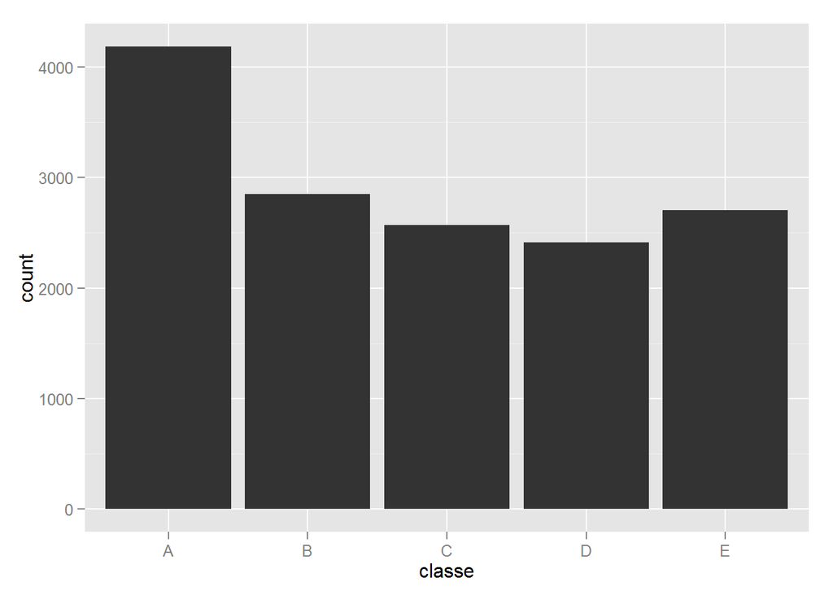

```r
g <- ggplot(data = training_part, aes(classe))
g <- g + geom_histogram()
g
```

## Prediction Model -1 (Decision Tree)

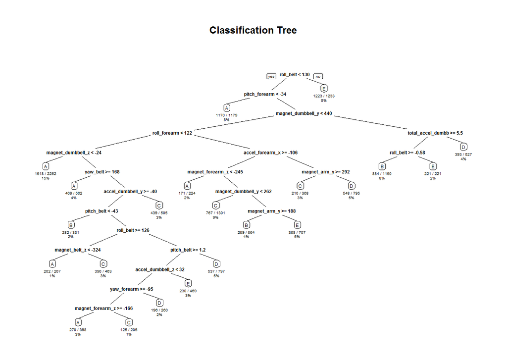

```r
model1 <- rpart(data = training_part, classe ~ ., method = "class")
prediction1 <- predict(model1, testing_part, type = "class")
rpart.plot(model1, main="Classification Tree", extra=102, under=TRUE, faclen=0)
```

```r
confusionMatrix(prediction1, testing_part$classe)
```

```
## Confusion Matrix and Statistics
##
##           Reference
## Prediction    A    B    C    D    E
##          A 1276  209   16   96   35
##          B   25  464   80   37   58
##          C   29  125  665   66   73
##          D   54   62   64  544   71
##          E   11   89   30   61  664
##
## Overall Statistics
##
##                Accuracy : 0.7367
##                  95% CI : (0.7242, 0.749)
##     No Information Rate : 0.2845
##     P-Value [Acc > NIR] : < 2.2e-16
##
##                   Kappa : 0.6653
##  Mcnemar's Test P-Value : < 2.2e-16
##
## Statistics by Class:
##
##                      Class: A Class: B Class: C Class: D Class: E
## Sensitivity            0.9147  0.48894   0.7778   0.6766   0.7370
## Specificity            0.8985  0.94943   0.9276   0.9388   0.9523
## Pos Pred Value         0.7819  0.69880   0.6942   0.6843   0.7766
## Neg Pred Value         0.9636  0.88561   0.9518   0.9367   0.9415
## Prevalence             0.2845  0.19352   0.1743   0.1639   0.1837
## Detection Rate         0.2602  0.09462   0.1356   0.1109   0.1354
## Detection Prevalence   0.3328  0.13540   0.1954   0.1621   0.1743
## Balanced Accuracy      0.9066  0.71918   0.8527   0.8077   0.8446
```

## Prediction Model -2 (random Forest)

```r
model2 <- randomForest(classe ~. , data=training_part, method="class")
prediction2 <- predict(model2, testing_part, type = "class")
confusionMatrix(prediction2, testing_part$classe)
```

```
## Confusion Matrix and Statistics
##
##           Reference
## Prediction    A    B    C    D    E
##          A 1395    9    0    0    0
##          B    0  940    5    0    0
##          C    0    0  850    8    0
##          D    0    0    0  794    0
##          E    0    0    0    2  901
##
## Overall Statistics
##
##                Accuracy : 0.9951
##                  95% CI : (0.9927, 0.9969)
##     No Information Rate : 0.2845
##     P-Value [Acc > NIR] : < 2.2e-16
##
##                   Kappa : 0.9938
##  Mcnemar's Test P-Value : NA
##
## Statistics by Class:
##
##                      Class: A Class: B Class: C Class: D Class: E
## Sensitivity            1.0000   0.9905   0.9942   0.9876   1.0000
## Specificity            0.9974   0.9987   0.9980   1.0000   0.9995
## Pos Pred Value         0.9936   0.9947   0.9907   1.0000   0.9978
## Neg Pred Value         1.0000   0.9977   0.9988   0.9976   1.0000
## Prevalence             0.2845   0.1935   0.1743   0.1639   0.1837
## Detection Rate         0.2845   0.1917   0.1733   0.1619   0.1837
## Detection Prevalence   0.2863   0.1927   0.1750   0.1619   0.1841
## Balanced Accuracy      0.9987   0.9946   0.9961   0.9938   0.9998
```

Since the accuracy for random Forest model is greater, we select the prediction model 2.